# SOYKOK Aylin 28711545

# CELIK Simay 28713301

# 1-e: Transformers

## [Course link](https://rdfia.github.io/)

# Warning :

# Do "File -> Save a copy in Drive" before you start modifying the notebook, otherwise your modifications will not be saved.

In this notebook, we will implement the first Visual Transformer, [ViT](https://arxiv.org/abs/2010.11929). We'll implement a naive version of it, much smaller than the ones described in the paper, and we also won't use complex data augmentation and regularizations. But note that this is important to make transformers work in practice on large-scale dataset.

To get a gist of what is required to make a transformer work in practice, have a look at the [DeiT and CaiT codebase](https://github.com/facebookresearch/deit).

This notebook is a simplified version of the excellent [Timm library](https://github.com/rwightman/pytorch-image-models).

```python
%pylab inline
```

```python
import pickle
import math

import numpy as np
import torch
from torch import nn
from torch.nn import functional as F
from torch.utils.data import DataLoader
from torchvision.datasets import ImageFolder
from torchvision import transforms
import torchvision.utils as vutils
import torchvision
from PIL import Image
```

Let's load the MNIST dataset:

```python
transform = transforms.Compose([
  transforms.ToTensor()
])

train_dataset = torchvision.datasets.MNIST('.', train=True, download=True, transform=transform)
test_dataset = torchvision.datasets.MNIST('.', train=False, download=True, transform=transform)


train_loader = DataLoader(train_dataset, batch_size=128, shuffle=True)
test_loader = DataLoader(test_dataset, batch_size=128)
```

... and visualize!

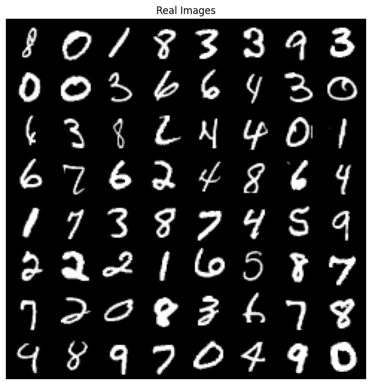

```python
real_batch = next(iter(train_loader))
plt.figure(figsize=(8,8))
plt.axis("off")
plt.title("Real Images")
plt.imshow(vutils.make_grid(real_batch[0][:64], normalize=True).permute(1,2,0))
plt.show()
```

# Here is the general architecture of the ViT model

## The architecture includes:

- A step for splitting the image into disjoint patches with a linear projection of the patches
- Positional encoding to capture the absolute spatial information of each patch in the image
- The addition of a "[CLS]" token, initialized randomly and learned during training
- A transformer encoder that learns the representation of each token
- A classification head that performs class prediction from the re-embedded [CLS] token at the output of the encoder

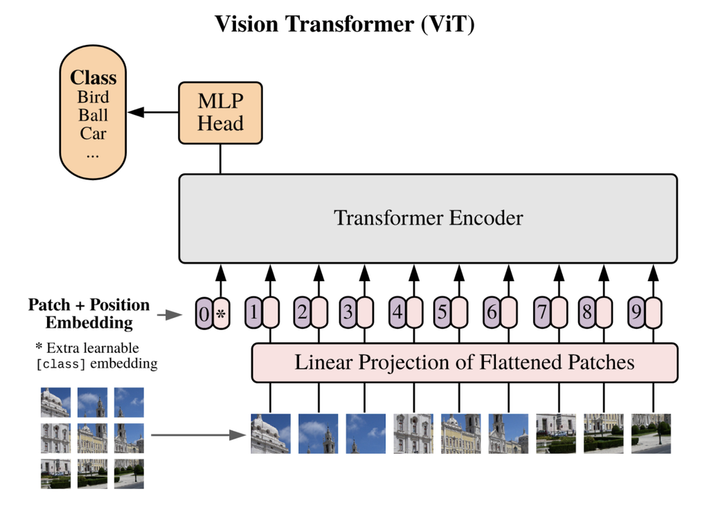

# Linear Projection of flattened patches

**Q1**: First, we need to code the patch embedding. In NLP, it could be using a word2vec embeddings, but we need something different in Computer Vision.

You are going to use a specific 2d convolution to play the role of the so-called "Linear Projection" on the image above and process each patch independently without overlap. Think a bit how you could do that.

Then, you need to manipulate the dimensions of the resulting tensor to get a final tensor of shape `(batch_size, nb_tokens, embedding_dim)`. *Hint: You will need a `view/reshape` and `transpose/permute` operators*.

As usual, remember to check the output shape of your layer by trying with a random tensor!

```python
class PatchEmbed(nn.Module):
  def __init__(self, in_chan=1, patch_size=7, embed_dim=128):
    super().__init__()
    ## TODO
    self.patch_size = patch_size
    self.projection = nn.Conv2d(in_channels=in_chan, out_channels=embed_dim, kernel_size=patch_size, stride=patch_size)

  def forward(self, x):
    x = self.projection(x)

    B, C, H, W = x.shape
    ## TODO


    # x.shape() -> B, N, C
    N = H * W #no need to divide by P because it's already done in convolution

    x = x.flatten(2) # flatten from B, C, H, W -> (B, C, H*W)
    x = x.permute(0, 2, 1) #  (B, N, C)

    assert x.shape[0]==B and x.shape[1]==N and x.shape[2]==C, f"Wrong shape : {(B,N,C)} VS {(x.shape[0],x.shape[1],x.shape[2])}"

    return x
```

```python
random_x = torch.rand(16, 1, 32, 32)
patch_embed = PatchEmbed()

x_emb = patch_embed(random_x)
print("x shape=",random_x.shape)
print("embedded shape=",x_emb.shape)
```

```
x shape= torch.Size([16, 1, 32, 32])
embedded shape= torch.Size([16, 16, 128])
```

# Transformer encoder

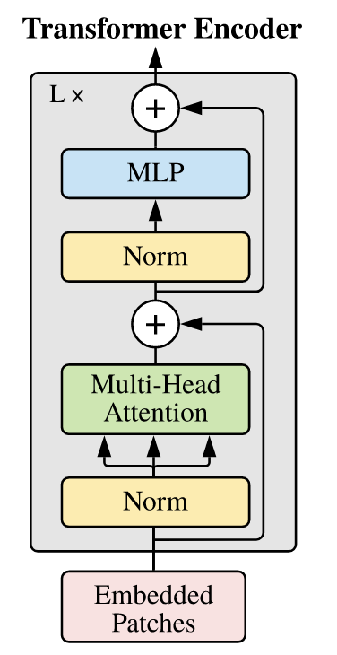

## Q2: MLP

Now we need to build a transformer block. Let's first build the easiest part, the MLP! By now, you should be confident how to code one.

Code a MLP with one hidden layer. Note that the input and output dimensions will be the same. Instead of ReLU, use the activation GELU, which is a slight alternative often used for transformers.

```python
class MLP(nn.Module):
  def __init__(self, in_features, hid_features):
    super().__init__()
    self.in_features = in_features
    self.hid_features = hid_features
    self.input = nn.Linear(self.in_features, self.hid_features)
    self.activ = nn.GELU()
    self.output = nn.Linear(self.hid_features, self.in_features)

  def forward(self, x):
    # TODO
    x = self.output(self.activ(self.input(x)))
    return x


MLP(128, 512)(torch.randn(32, 16, 128)).shape
```

```
torch.Size([32, 16, 128])
```

## Q3: Self-attention

Now we are going to build the famous **Self-Attention**.

- What is the main feature of self-attention, especially compared to its convolutional counterpart. What is its main challenge in terms of computation/memory?
- At first, we are going to only consider the simple case of one head. Write the equations and complete the following code. And don't forget a final linear projection at the end!

```python
class SelfAttention(nn.Module):
  def __init__(self, embed_dim):
    super().__init__()

    # TODO
    self.embed_dim = embed_dim
    self.WQ = nn.Linear(self.embed_dim, self.embed_dim)
    self.WK = nn.Linear(self.embed_dim, self.embed_dim)
    self.WV = nn.Linear(self.embed_dim, self.embed_dim)
    self.lin_projection = nn.Linear(self.embed_dim, self.embed_dim)
    self.scale = self.embed_dim ** -0.5

  def forward(self, x):
    B, N, C = x.shape

    # TODO: compute the Q, K, V
    q = self.WQ(x)
    k = self.WK(x)
    v = self.WV(x)

    # TODO: compute the attention matrix using Q and K
    attention = F.softmax(torch.matmul(q, k.transpose(-2, -1))*self.scale, dim=-1)

    # TODO: compute the final version using the attention,
    # V, and the final projection
    x = torch.matmul(attention, v)
    x = self.lin_projection(x)
    return x


SelfAttention(128)(torch.randn(32, 16, 128)).shape
```

```
torch.Size([32, 16, 128])
```

# Q4 : Multi-head self-attention

Now we need to build a Multi-Heads Self-Attention.

- Write the equations and complete the following code to build a Multi-Heads Self-Attention.
- The total embedding size will be shared equally among all heads.

```python
class MultiHeadsSelfAttention(nn.Module):
  def __init__(self, embed_dim, num_heads):
    super().__init__()

    self.embed_dim = embed_dim
    head_dim =  embed_dim // num_heads
    self.head_dim = head_dim
    self.scale = head_dim ** -0.5
    self.num_heads = num_heads

    self.q = nn.Linear(self.embed_dim, self.embed_dim)
    self.k = nn.Linear(self.embed_dim, self.embed_dim)
    self.v = nn.Linear(self.embed_dim, self.embed_dim)
    self.projection = nn.Linear(self.embed_dim, self.embed_dim)

  def forward(self, x):
    B, N, C = x.shape

    q = self.q(x) # B, N, C
    k = self.k(x) # B, N, C
    v = self.v(x) # B, N, C

    # You need to reshape and permute dimension in a certain manner
    # so that each head (C // num_heads) interact
    # only with its dimensions and not other heads.

    # Try to write at each operation the shape of the tensor if you
    # feel confused.

    # TODO
    q = q.view(B, N, self.num_heads, self.head_dim).permute(0, 2, 1, 3) # B, num_heads, N, head_dim
    k = k.view(B, N, self.num_heads, self.head_dim).permute(0, 2, 1, 3) # B, num_heads, N, head_dim
    v = v.view(B, N, self.num_heads, self.head_dim).permute(0, 2, 1, 3) # B, num_heads, N, head_dim


    score = torch.matmul(q, k.transpose(-2, -1))* self.scale
    #print(score.shape)

    # shape of k^T -> B, num_heads, head_dim, N
    # shape q * k^T -> B, num_heads, N, N

    attention = F.softmax(score, dim=-1) # B, num_heads, N, N
    #print(attention.shape)

    Z = torch.matmul(attention, v) # B, num_heads, N, head_dim
    #print(Z.shape)


    x = self.projection(Z.view(B, N, C)) # last dim needs to be C in order to be compatible with the projection layer's shape

    return x

x = torch.randn(8, 12, 6) # random tensor to test
MultiHeadsSelfAttention(6, 2)(x).shape
```

```
torch.Size([8, 12, 6])
```

# Q5: Transfomer block

Now, we need to build a Transformer **Block** as described in the image below.

- Write the equations and complete the following code.
- For the Layer Normalization, use PyTorch LayerNorm: https://pytorch.org/docs/stable/generated/torch.nn.LayerNorm.html

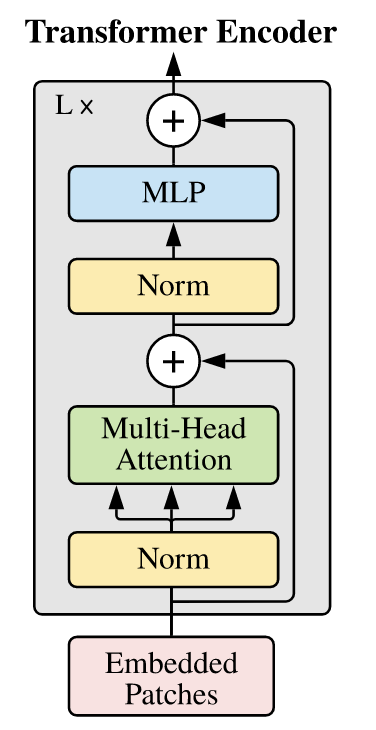

```python
class Block(nn.Module):
  def __init__(self, embed_dim, num_heads=4, mlp_ratio=4):
    super().__init__()

    # TODO
    self.embed_dim = embed_dim
    self.num_heads = num_heads
    self.mlp_ratio = mlp_ratio

    self.norm1 = nn.LayerNorm(embed_dim)
    self.multihead_attention = MultiHeadsSelfAttention(embed_dim, num_heads)
    self.norm2 = nn.LayerNorm(embed_dim)
    self.mlp = MLP(embed_dim, mlp_ratio*embed_dim)

  def forward(self, x):
    # TODO
    n1 = self.norm1(x)
    att = self.multihead_attention(n1)
    n2 = self.norm2(x + att)
    ffn = self.mlp(n2)
    x = ffn + x + att
    return x

Block(128)(torch.randn(32, 16, 128)).shape
```

```
torch.Size([32, 16, 128])
```

# Q6: Full ViT model

Now you need to build a ViT model based on what you coded in the previous questions. There are additional components that should be coded such as the Class token, Positional embedding and the classification head.

- Explain what is a Class token and why we use it? \
- Explain whay is the the positional embedding (PE) and why it is important? \

For PE, you can use a sinusoidal encoding (see below), or fully learned.

### Sinusoidal PE

```python
def get_positional_embeddings(sequence_length, d):
    result = torch.ones(1,sequence_length, d)
    for i in range(sequence_length):
        for j in range(d):
            result[0][i][j] = np.sin(i / (10000 ** (j / d))) if j % 2 == 0 else np.cos(i / (10000 ** ((j - 1) / d)))
    return result
```

```python
class ViT(nn.Module):
  def __init__(self, embed_dim, nb_blocks, patch_size, nb_classes=10):
    super().__init__()

    num_patches = (28 // patch_size) ** 2

    self.class_token = nn.Parameter(torch.randn(1,1, embed_dim))
    self.pos_embed = nn.Parameter(get_positional_embeddings(1+num_patches, embed_dim))
    self.patch_embed = PatchEmbed(patch_size=patch_size, embed_dim=embed_dim)

    blocks = []
    for _ in range(nb_blocks):
      blocks.append(
          Block(embed_dim)
      )
    self.blocks = nn.Sequential(*blocks)

    self.norm = nn.LayerNorm(embed_dim)
    self.head = nn.Linear(embed_dim, nb_classes)

  def forward(self, x):
    x = self.patch_embed(x) ## image to patches

    ## concatenating class token

    class_token = self.class_token.repeat(x.shape[0], 1, 1) # repeat it batch size times
    x = torch.cat((class_token, x), dim=1)

    ## adding positional embedding
    x = x + self.pos_embed.repeat(x.shape[0], 1, 1)

    ## forward in the transformer
    x = self.blocks(x)

    ## Normalize the output
    x = self.norm(x)

    #print(x.shape) -> [32, 17, 128]: batch size, sequence_length (1+num_patches), embed_dim
    # using x[:, 0, :] -> the first elem of the 2nd dim contains the cls token
    # bcs we prepend it to the patch tokens
    output = self.head(x[:, 0, :]) ## classification output

    return output


ViT(128, 3, 7)(torch.randn(32, 1, 28, 28)).shape
```

```
torch.Size([32, 10])
```

# Q7: Experiment on MNIST!

A quick function to evaluate our model:

```python
@torch.no_grad()
def eval_model(model, loader):
  model.eval()
  acc = 0.
  c = 0

  for x, y in loader:
    x, y = x.cuda(), y.cuda()
    yhat = model(x)

    acc += torch.sum(yhat.argmax(dim=1) == y).cpu().item()
    c += len(x)

  model.train()
  return round(100 * acc / c, 2)
```

And run! Feel free to try other hyperparameters.

```python
epochs = 10

embed_dim = 32
patch_size = 7
nb_blocks = 2

model = ViT(embed_dim, nb_blocks, patch_size).cuda()

opt = torch.optim.Adam(model.parameters())

for epoch in range(epochs):
  train_loss = 0.
  for x, y in train_loader:
    x, y = x.cuda(), y.cuda()

    opt.zero_grad()
    yhat = model(x)
    loss = F.cross_entropy(yhat, y)
    loss.backward()

    opt.step()

    train_loss += loss.item()

  print(f"--- Epoch {epoch} ---")
  print(f"Train loss: {train_loss / len(train_loader)}")
acc = eval_model(model, test_loader)
print(f"Test accuracy: {acc}")
```

```
--- Epoch 0 ---
Train loss: 0.812539194724453
--- Epoch 1 ---
Train loss: 0.22641983583791933
--- Epoch 2 ---
Train loss: 0.16663157459356384
--- Epoch 3 ---
Train loss: 0.137322179818236
--- Epoch 4 ---
Train loss: 0.11810077295930528
--- Epoch 5 ---
Train loss: 0.10496402131929708
--- Epoch 6 ---
Train loss: 0.092131335014251
--- Epoch 7 ---
Train loss: 0.08586635037478227
--- Epoch 8 ---
Train loss: 0.0784104123953849
--- Epoch 9 ---
Train loss: 0.07152366231102297
Test accuracy: 96.79
```

# Experimental analysis

- Test different hyperparameters and explain how they affect the performance. In particular embed_dim, patch_size, and nb_blocks.
- Comment and discuss the final performance that you get. How to improve it?
- What is the complexity of the transformer in terms of number of tokens? How you can improve it?

```python
def train_and_evaluate(embed_dim, patch_size, nb_blocks, epochs=10, verbose=True):
    model = ViT(embed_dim, nb_blocks, patch_size).cuda()
    opt = torch.optim.Adam(model.parameters())

    train_losses = []
    test_accuracies = []
    test_losses = []
    train_accuracies = []
    for epoch in range(epochs):
        train_loss = 0.
        train_acc = 0
        train_count = 0
        for x, y in train_loader:
            x, y = x.cuda(), y.cuda()

            opt.zero_grad()
            yhat = model(x)
            loss = F.cross_entropy(yhat, y)
            loss.backward()

            opt.step()

            train_loss += loss.item()
            train_acc += (yhat.argmax(dim=1) == y).sum().item()
            train_count += len(x)

        train_losses.append(train_loss / len(train_loader))
        train_accuracies.append(train_acc / train_count * 100)

        test_loss = 0
        test_acc = 0
        test_count = 0

        with torch.no_grad():
            for x, y in test_loader:
                x, y = x.cuda(), y.cuda()
                yhat = model(x)
                loss = F.cross_entropy(yhat, y)
                test_loss += loss.item()
                test_acc += (yhat.argmax(dim=1) == y).sum().item()
                test_count += len(x)
        test_losses.append(test_loss / len(test_loader))
        test_accuracies.append(test_acc / test_count * 100)

        if verbose:
            print(f"--- Epoch {epoch} ---")
            print(f"Train loss: {train_losses[-1]}")
            print(f"Train Accuracy: {train_accuracies[-1]}")
            print(f"Test loss: {test_losses[-1]}")
            print(f"Test Accuracy: {test_accuracies[-1]}")

    return train_losses, test_losses, train_accuracies, test_accuracies
```

```python
results = {}
embed_dims = [32,64,128]
for embed_dim in embed_dims:
    print(f"Training with embed_dim={embed_dim}")
    results[embed_dim] = {}
    train_losses, test_losses, train_accuracies, test_accuracies = train_and_evaluate(embed_dim, 7, 2,verbose=False)
    results[embed_dim]['train_losses'] = train_losses
    results[embed_dim]['test_losses'] = test_losses
    results[embed_dim]['train_accuracies'] = train_accuracies
    results[embed_dim]['test_accuracies'] = test_accuracies
```

```
Training with embed_dim=32
Training with embed_dim=64
Training with embed_dim=128
```

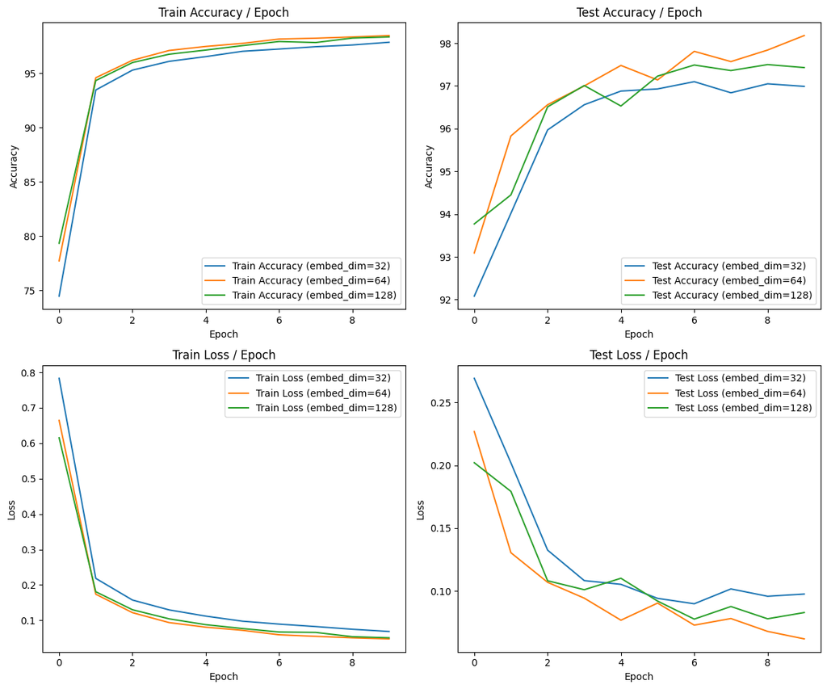

```python
fig, axs = plt.subplots(2, 2, figsize=(12, 10))


# Training Accuracy
for embed_dim in embed_dims:
    axs[0, 0].plot(results[embed_dim]['train_accuracies'], label=f'Train Accuracy (embed_dim={embed_dim})')
axs[0, 0].set_title('Train Accuracy / Epoch')
axs[0, 0].set_xlabel('Epoch')
axs[0, 0].set_ylabel('Accuracy')
axs[0, 0].legend()

# Test Accuracy
for embed_dim in embed_dims:
    axs[0, 1].plot(results[embed_dim]['test_accuracies'], label=f'Test Accuracy (embed_dim={embed_dim})')
axs[0, 1].set_title('Test Accuracy / Epoch')
axs[0, 1].set_xlabel('Epoch')
axs[0, 1].set_ylabel('Accuracy')
axs[0, 1].legend()

# Training Loss
for embed_dim in embed_dims:
    axs[1, 0].plot(results[embed_dim]['train_losses'], label=f'Train Loss (embed_dim={embed_dim})')
axs[1, 0].set_title('Train Loss / Epoch')
axs[1, 0].set_xlabel('Epoch')
axs[1, 0].set_ylabel('Loss')
axs[1, 0].legend()

# Test Loss
for embed_dim in embed_dims:
    axs[1, 1].plot(results[embed_dim]['test_losses'], label=f'Test Loss (embed_dim={embed_dim})')
axs[1, 1].set_title('Test Loss / Epoch')
axs[1, 1].set_xlabel('Epoch')
axs[1, 1].set_ylabel('Loss')
axs[1, 1].legend()

plt.tight_layout()
plt.show()
```

```python
results = {}
patch_sizes = [3,4,5,6,7,8]
for patch_size in patch_sizes:
    print(f"Training with patch_size={patch_size}")
    results[patch_size] = {}
    train_losses, test_losses, train_accuracies, test_accuracies = train_and_evaluate(64, patch_size, 2,verbose=False)
    results[patch_size]['train_losses'] = train_losses
    results[patch_size]['test_losses'] = test_losses
    results[patch_size]['train_accuracies'] = train_accuracies
    results[patch_size]['test_accuracies'] = test_accuracies
```

```
Training with patch_size=3
Training with patch_size=4
Training with patch_size=5
Training with patch_size=6
Training with patch_size=7
Training with patch_size=8
```

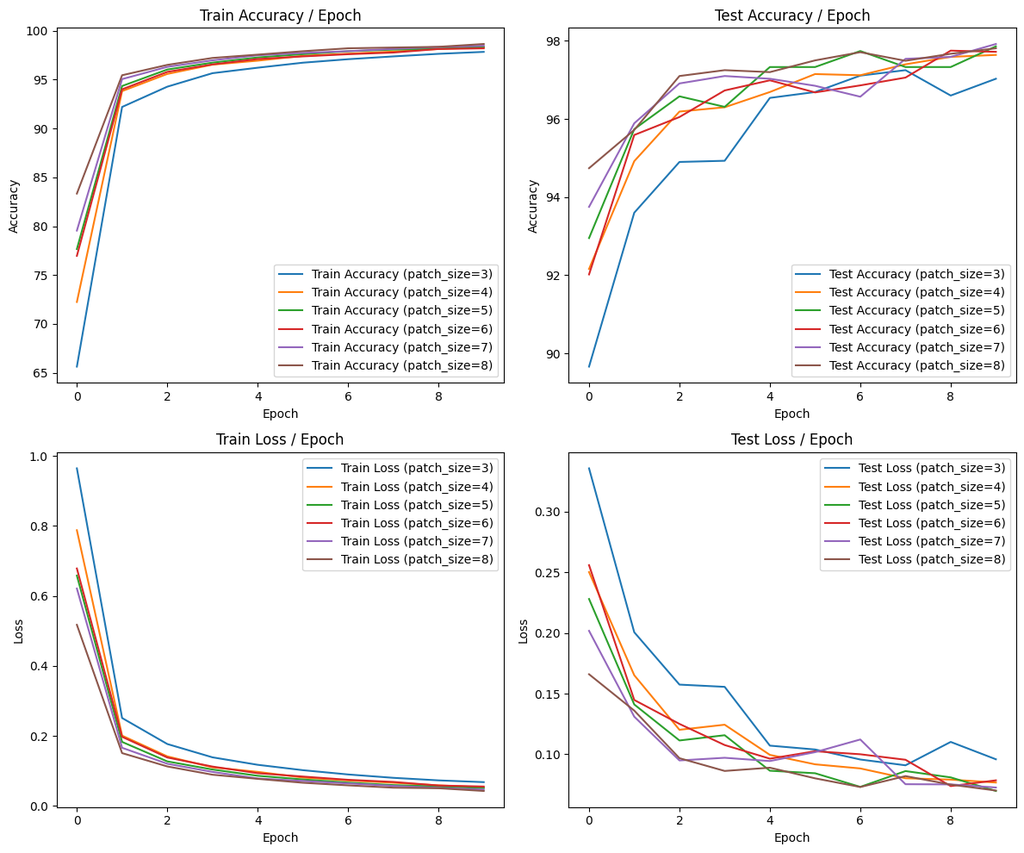

```python
fig, axs = plt.subplots(2, 2, figsize=(12, 10))


# Training Accuracy
for patch_size in patch_sizes:
    axs[0, 0].plot(results[patch_size]['train_accuracies'], label=f'Train Accuracy (patch_size={patch_size})')
axs[0, 0].set_title('Train Accuracy / Epoch')
axs[0, 0].set_xlabel('Epoch')
axs[0, 0].set_ylabel('Accuracy')
axs[0, 0].legend()

# Test Accuracy
for patch_size in patch_sizes:
    axs[0, 1].plot(results[patch_size]['test_accuracies'], label=f'Test Accuracy (patch_size={patch_size})')
axs[0, 1].set_title('Test Accuracy / Epoch')
axs[0, 1].set_xlabel('Epoch')
axs[0, 1].set_ylabel('Accuracy')
axs[0, 1].legend()

# Training Loss
for patch_size in patch_sizes:
    axs[1, 0].plot(results[patch_size]['train_losses'], label=f'Train Loss (patch_size={patch_size})')
axs[1, 0].set_title('Train Loss / Epoch')
axs[1, 0].set_xlabel('Epoch')
axs[1, 0].set_ylabel('Loss')
axs[1, 0].legend()

# Test Loss
for patch_size in patch_sizes:
    axs[1, 1].plot(results[patch_size]['test_losses'], label=f'Test Loss (patch_size={patch_size})')
axs[1, 1].set_title('Test Loss / Epoch')
axs[1, 1].set_xlabel('Epoch')
axs[1, 1].set_ylabel('Loss')
axs[1, 1].legend()

plt.tight_layout()
plt.show()
```

```python
results = {}
nb_blocks_list = [1,2,3,4,5]
for nb_blocks in nb_blocks_list:
    print(f"Training with nb_blocks={nb_blocks}")
    results[nb_blocks] = {}
    train_losses, test_losses, train_accuracies, test_accuracies = train_and_evaluate(64, 7, nb_blocks,verbose=False)
    results[nb_blocks]['train_losses'] = train_losses
    results[nb_blocks]['test_losses'] = test_losses
    results[nb_blocks]['train_accuracies'] = train_accuracies
    results[nb_blocks]['test_accuracies'] = test_accuracies
```

```
Training with nb_blocks=1
Training with nb_blocks=2
Training with nb_blocks=3
Training with nb_blocks=4
Training with nb_blocks=5
```

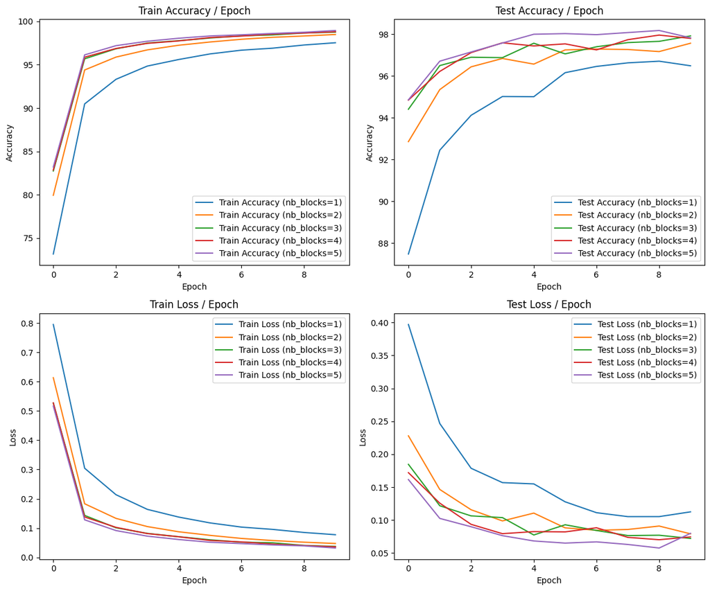

```python
fig, axs = plt.subplots(2, 2, figsize=(12, 10))


# Training Accuracy
for nb_blocks in nb_blocks_list:
    axs[0, 0].plot(results[nb_blocks]['train_accuracies'], label=f'Train Accuracy (nb_blocks={nb_blocks})')
axs[0, 0].set_title('Train Accuracy / Epoch')
axs[0, 0].set_xlabel('Epoch')
axs[0, 0].set_ylabel('Accuracy')
axs[0, 0].legend()

# Test Accuracy
for nb_blocks in nb_blocks_list:
    axs[0, 1].plot(results[nb_blocks]['test_accuracies'], label=f'Test Accuracy (nb_blocks={nb_blocks})')
axs[0, 1].set_title('Test Accuracy / Epoch')
axs[0, 1].set_xlabel('Epoch')
axs[0, 1].set_ylabel('Accuracy')
axs[0, 1].legend()

# Training Loss
for nb_blocks in nb_blocks_list:
    axs[1, 0].plot(results[nb_blocks]['train_losses'], label=f'Train Loss (nb_blocks={nb_blocks})')
axs[1, 0].set_title('Train Loss / Epoch')
axs[1, 0].set_xlabel('Epoch')
axs[1, 0].set_ylabel('Loss')
axs[1, 0].legend()

# Test Loss
for nb_blocks in nb_blocks_list:
    axs[1, 1].plot(results[nb_blocks]['test_losses'], label=f'Test Loss (nb_blocks={nb_blocks})')
axs[1, 1].set_title('Test Loss / Epoch')
axs[1, 1].set_xlabel('Epoch')
axs[1, 1].set_ylabel('Loss')
axs[1, 1].legend()

plt.tight_layout()
plt.show()
```

# Q8: larger transformers

Try to use bigger transformer, for example the ViT-S from the timm library. Test with and without intialization from imagenet.

```python
!pip install timm
```

a) Load the model using the timm library without pretrained wewights. Try to apply it directly on a tensor with the same MNIST images resolution. What it is the problem and why we have it? Explain if we have also such problem with CNNs. As ViT takes RGB images, the input tensor should have 3 channels.

```python
import timm
model = None
```

```python
x = torch.randn(32, 1, 28, 28)
model = timm.create_model('vit_small_patch16_224', pretrained=False, num_classes=10)# adapt number of channels to fit in ViT
model(x).shape
```

[output not shown]

[output cut: 9 more lines]

[output not shown]

b) There is a trcik in timm that allows to use pretrained models with different image resolution and number of classes. Try to reload the model to be able to use on MNIST images:

```python
model = timm.create_model(
    'vit_small_patch16_224', pretrained=False, num_classes=10, img_size=(28, 28)          )
model(torch.randn(32, 3, 28, 28)).shape
```

```
torch.Size([32, 10])
```

```python
@torch.no_grad()
def eval_model(model, loader, num_channels=1):
  model.eval()
  acc = 0.
  c = 0
  total_loss = 0.

  for x, y in loader:
    x, y = x.cuda(), y.cuda()
    x = x.repeat(1, 3, 1, 1)  # adapt number of channels to fit in ViT =>  (batch_size, 3, 28, 28)

    yhat = model(x)
    loss = F.cross_entropy(yhat, y)
    total_loss += loss.item() * len(x)

    acc += torch.sum(yhat.argmax(dim=1) == y).cpu().item()
    c += len(x)

  model.train()
  avg_loss = total_loss / c
  accuracy = round(100 * acc / c, 2)
  return accuracy, avg_loss
```

# untrained

```python
model.cuda()
# model.train()

epochs = 10

opt = torch.optim.Adam(model.parameters())
train_losses = []
test_losses = []
train_acc = []
test_acc = []
for epoch in range(epochs):
  train_loss = 0.
  for x, y in train_loader:
    x, y = x.cuda(), y.cuda()

    opt.zero_grad()
    x = x.repeat(1, 3, 1, 1) # adapt number of channels to fit in ViT =>  (batch_size, 3, 28, 28)
    yhat = model(x)
    loss = F.cross_entropy(yhat, y)
    loss.backward()

    opt.step()

    train_loss += loss.item()

  print(f"--- Epoch {epoch} ---")
  print(f"Train loss: {train_loss / len(train_loader)}")
  train_a, train_l = eval_model(model, train_loader, num_channels=3)
  test_a, test_l = eval_model(model, test_loader, num_channels=3)
  train_losses.append(train_l)
  test_losses.append(test_l)
  train_acc.append(train_a)
  test_acc.append(test_a)

acc = eval_model(model, test_loader, num_channels=3)
print(f"Test accuracy: {acc}")
```

```
--- Epoch 0 ---
Train loss: 0.844800232824232
--- Epoch 1 ---
Train loss: 0.560449996037778
--- Epoch 2 ---
Train loss: 0.4922170147839894
--- Epoch 3 ---
Train loss: 0.4491516049546219
--- Epoch 4 ---
Train loss: 0.42660907571758033
--- Epoch 5 ---
Train loss: 0.40249521731694876
--- Epoch 6 ---
Train loss: 0.3829419841008908
--- Epoch 7 ---
Train loss: 0.3701225570015816
--- Epoch 8 ---
Train loss: 0.35049330918138216
--- Epoch 9 ---
Train loss: 0.3436900692771493
Test accuracy: (87.0, 0.3786746096611023)
```

c) redo the training with the pretrained ViT-S

c) redo the training but with the ViT-S pretrained on ImageNet

```python
model = timm.create_model('vit_small_patch16_224',
                          pretrained=True,
                          num_classes=10,
                          img_size=(28, 28)
          ).cuda()
model.train()
```

[output not shown]

[output cut: 248 more lines]

[output not shown]

```python
model.cuda()
# model.train()

epochs = 10

opt = torch.optim.Adam(model.parameters())
pretrain_losses = []
pretest_losses = []
pretrain_acc = []
pretest_acc = []
for epoch in range(epochs):
  train_loss = 0.
  for x, y in train_loader:
    x, y = x.cuda(), y.cuda()

    opt.zero_grad()
    x = x.repeat(1, 3, 1, 1) # adapt number of channels to fit in ViT =>  (batch_size, 3, 28, 28)
    yhat = model(x)
    loss = F.cross_entropy(yhat, y)
    loss.backward()

    opt.step()

    train_loss += loss.item()

  print(f"--- Epoch {epoch} ---")
  print(f"Train loss: {train_loss / len(train_loader)}")
  train_a, train_l = eval_model(model, train_loader, num_channels=3)
  test_a, test_l = eval_model(model, test_loader, num_channels=3)
  pretrain_losses.append(train_l)
  pretest_losses.append(test_l)
  pretrain_acc.append(train_a)
  pretest_acc.append(test_a)

acc = eval_model(model, test_loader, num_channels=3)
print(f"Test accuracy: {acc}")
```

```
--- Epoch 0 ---
Train loss: 0.5594216189913149
--- Epoch 1 ---
Train loss: 0.33191834072441434
--- Epoch 2 ---
Train loss: 0.28428862258188253
--- Epoch 3 ---
Train loss: 0.26045431944924885
--- Epoch 4 ---
Train loss: 0.24054306697870878
--- Epoch 5 ---
Train loss: 0.21925146454401107
--- Epoch 6 ---
Train loss: 0.20489747196372385
--- Epoch 7 ---
Train loss: 0.19114829447350776
--- Epoch 8 ---
Train loss: 0.18161507336093163
--- Epoch 9 ---
Train loss: 0.17035850791979446
Test accuracy: (91.29, 0.2829917798757553)
```

d) Comment the final results and provide some ideas on how to make transformer work on small datasets. You can take inspiration from some recent work.

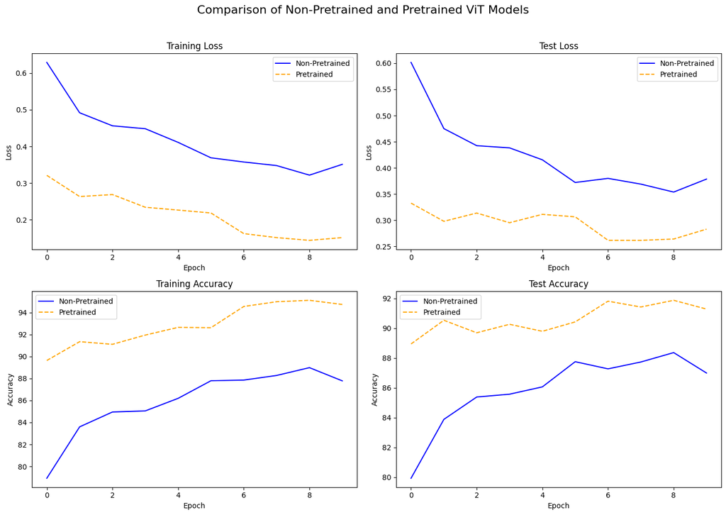

```python
import matplotlib.pyplot as plt
fig, axs = plt.subplots(2, 2, figsize=(14, 10))
fig.suptitle("Comparison of Non-Pretrained and Pretrained ViT Models", fontsize=16)

# Training Loss
axs[0, 0].plot(train_losses, label="Non-Pretrained", color="blue", linestyle="-")
axs[0, 0].plot(pretrain_losses, label="Pretrained", color="orange", linestyle="--")
axs[0, 0].set_title("Training Loss")
axs[0, 0].set_xlabel("Epoch")
axs[0, 0].set_ylabel("Loss")
axs[0, 0].legend()

# Test Loss
axs[0, 1].plot(test_losses, label="Non-Pretrained", color="blue", linestyle="-")
axs[0, 1].plot(pretest_losses, label="Pretrained", color="orange", linestyle="--")
axs[0, 1].set_title("Test Loss")
axs[0, 1].set_xlabel("Epoch")
axs[0, 1].set_ylabel("Loss")
axs[0, 1].legend()

# Training Accuracy
axs[1, 0].plot(train_acc, label="Non-Pretrained", color="blue", linestyle="-")
axs[1, 0].plot(pretrain_acc, label="Pretrained", color="orange", linestyle="--")
axs[1, 0].set_title("Training Accuracy")
axs[1, 0].set_xlabel("Epoch")
axs[1, 0].set_ylabel("Accuracy")
axs[1, 0].legend()

# Test Accuracy
axs[1, 1].plot(test_acc, label="Non-Pretrained", color="blue", linestyle="-")
axs[1, 1].plot(pretest_acc, label="Pretrained", color="orange", linestyle="--")
axs[1, 1].set_title("Test Accuracy")
axs[1, 1].set_xlabel("Epoch")
axs[1, 1].set_ylabel("Accuracy")
axs[1, 1].legend()

plt.tight_layout(rect=[0, 0, 1, 0.96])
plt.show()
```